# Castration extends lifespans of both male and female by 15%

## Summarise the dataset

Note that ES have not been calculated yet (use prelim.R code to do so).

Look at the overall pattern of missing data.

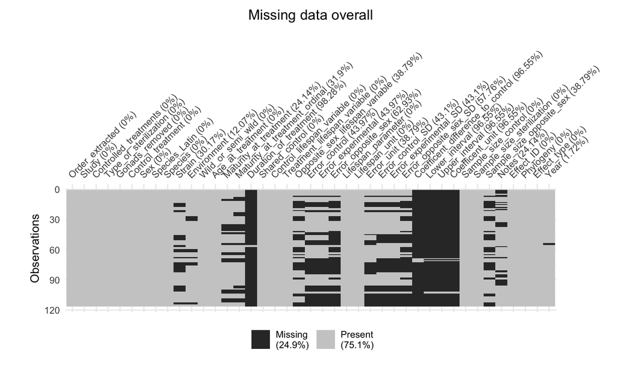

### General summary

- Number of effect sizes: 116
- Number of studies: 50
- Publication years: from 1930 to 2021
- Simple list of studies as short references: Arriola Apelo et al 2020, Asdell and Joshi 1976, Asdell et al 1967, Benedusi et al 2015, Bronson 1981, Bronson 1982, Cargil et al 2003, Cheng 2019, Cox and Calsbeek 2010, Cox et al 2010, Cox et al 2014, Dorner 1973, Drori and Folman 1976, Garratt et al 2021, Gipps and Jewel 1979, Hamilton 1965, Hamilton and Mestler 1969, Hamilton et al 1969, Hoffman et al 2018, Holland et al 1997, Huang et al 2017, Iwasa et al 2018, Jacob et al 2004 A, Jacob et al 2004 B, Jewel 1997, Kirkman and Yau, Kirkpatrick and Turner 2004, Mason et al 2009, Min et al 2012, Mitchel et al 1999, Moore et al 2001, Muhlock 1959, Nieschlag et al 1993, Oneil et al 2013, Oneil et al 2015, Parker et al 2013, Ramsey 2005, Ramsey et al 2021, Reedy et al 2016, Sichuk 1965, Slonaker 1930, Storer et al 1982, Talbert and Hamilton 1965, Tapprest et al 2017, Twigg et al 2000, Urfer et al 2019, Waters et al 2011, Williams et al 2007, Wilson et al 2019, Zakeri et al 2019
- Number of species: 14
- Simple list of species Latin names (also stored in “Phylogeny” variable): Mus musculus, Rattus norvegicus, Felis catus, Canis lupus, Anolis sagrei, Myodes glareolus, Homo sapiens, Rattus argentiventer, Ovis aries, Mesocricetus auratus, Equus ferus, Trichosurus vulpecula, Phascolarctos cinereus, Oryctolagus cuniculus
- Number of data points for females: 68, and data points form males: 48

```r
# Key variables: Sex, Gonads_removed, Wild_or_semi_wild, Controlled_treatments,
# Effect_type, Maturity_at_treatment_ordinal (ordinal with NA), names(dat)

# check how crossed with Sex (relevant to both sexes or not?)
table(dat$Species_Latin, dat$Sex)
table(dat$Wild_or_semi_wild, dat$Sex)
table(dat$Gonads_removed, dat$Sex)  #always Yes in Males
table(dat$Controlled_treatments, dat$Sex)
table(dat$Maturity_at_treatment_ordinal, dat$Sex)  #table(dat$Maturity_at_treatment)
table(dat$Effect_type, dat$Sex)

# check how crossed with Wild_or_semi_wild
table(dat$Gonads_removed, dat$Wild_or_semi_wild)
table(dat$Controlled_treatments, dat$Wild_or_semi_wild)
table(dat$Maturity_at_treatment_ordinal, dat$Wild_or_semi_wild)
table(dat$Effect_type, dat$Wild_or_semi_wild)

# check how crossed with Gonads_removed
table(dat$Wild_or_semi_wild, dat$Gonads_removed)
table(dat$Controlled_treatments, dat$Gonads_removed)
table(dat$Maturity_at_treatment_ordinal, dat$Gonads_removed)
table(dat$Effect_type, dat$Gonads_removed)

# check how crossed with Controlled_treatments
table(dat$Wild_or_semi_wild, dat$Controlled_treatments)
table(dat$Gonads_removed, dat$Controlled_treatments)
table(dat$Maturity_at_treatment_ordinal, dat$Controlled_treatments)
table(dat$Effect_type, dat$Controlled_treatments)

# check how crossed with Effect_type
table(dat$Wild_or_semi_wild, dat$Effect_type)
table(dat$Gonads_removed, dat$Effect_type)
table(dat$Controlled_treatments, dat$Effect_type)
table(dat$Maturity_at_treatment_ordinal, dat$Effect_type)
```

### Key predictors (moderators)

Visualise missing data in 6 key variables (moderators):  
- Sex,  
- Wild_or_semi_wild,  
- Maturity_at_treatment_ordinal,  
- Gonads_removed,  
- Controlled_treatments,  
- Effect_type

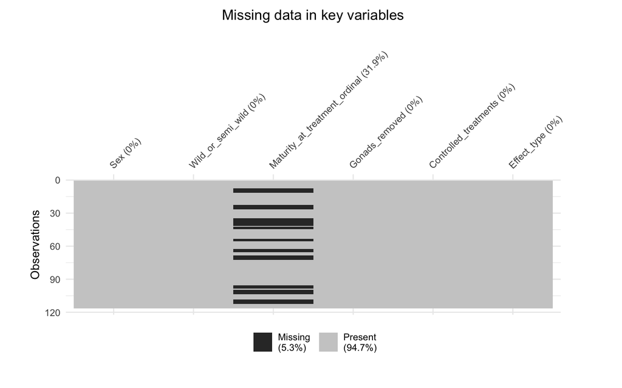

Visualise pairwise associations between 6 key variables:

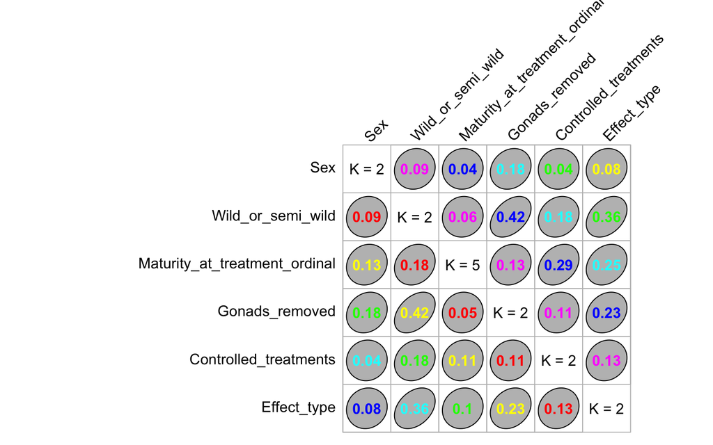

Alluvial diagrams for key predictor variables (moderators) - two groups of 3 moderators, grouped by similarity:

A. For Sex, Gonads_removed, Maturity_at_treatment_ordinal (changed NA to 0)

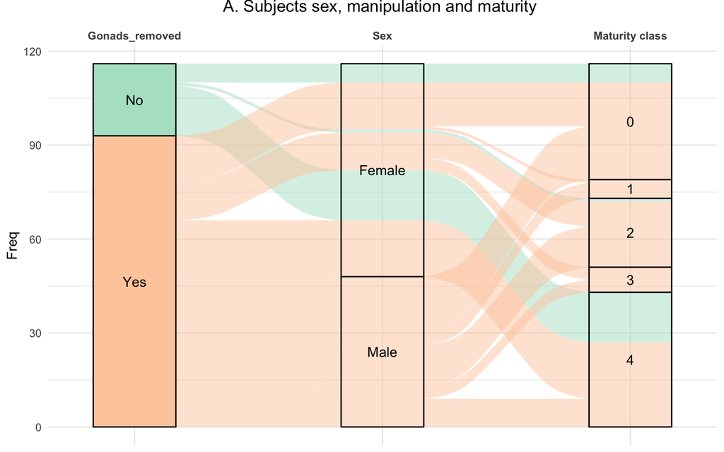

```r
# use ggalluvial
# (https://cran.r-project.org/web/packages/ggalluvial/vignettes/ggalluvial.html)

# create a frequency table for first 3 moderator variables freq_1 <-
# as.data.frame(table(dat$Sex, dat$Gonads_removed,
# dat$Maturity_at_treatment_ordinal)) %>% rename(Sex = Var1, Gonads_removed =
# Var2, Maturity_at_treatment_ordinal = Var3)
# is_alluvia_form(as.data.frame(freq_1), axes = 1:3, silent = TRUE) #freq_1 %>%
# filter(Freq != 0) %>% arrange(desc(Freq)) #collapesd table of values, without
# 0s


# ggplot(data = freq_1, aes(axis1 = Sex, axis2 = Gonads_removed, axis3 =
# Maturity_at_treatment_ordinal, y = Freq)) + geom_alluvium(aes(fill = Sex)) +
# geom_stratum(aes(fill = Sex))+ geom_text(stat = 'stratum', aes(label =
# after_stat(stratum))) + #theme_minimal() + theme_void() + theme(legend.position
# = 'none', plot.title = element_text(hjust = 0.5, vjust = 3), axis.title.x =
# element_text(), axis.text.x = element_text(face='bold')) +
# scale_x_discrete(limits = c('Sex', 'Gonads removed', 'Maturity class'), expand
# = c(0.15, 0.05), position = 'top') + scale_fill_brewer(palette = 'Set3') +
# ggtitle('A. Subjects sex, manipulation type and maturity class')

# as above but with, but with Gonads_removed as first column, and different
# colours ggplot(data = freq_1, aes(axis1 = Gonads_removed, axis2 = Sex, axis3 =
# Maturity_at_treatment_ordinal, y = Freq)) + geom_alluvium(aes(fill =
# Gonads_removed)) + geom_stratum(aes(fill = Gonads_removed))+ geom_text(stat =
# 'stratum', aes(label = after_stat(stratum))) + theme_minimal() + # theme_void()
# + theme(legend.position = 'none', plot.title = element_text(hjust = 0.5, vjust
# = 3), axis.title.x = element_text(), axis.text.x = element_text(face='bold')) +
# scale_x_discrete(limits = c('Gonads_removed', 'Sex', 'Maturity class'), expand
# = c(0.15, 0.05), position = 'top') + scale_fill_brewer(palette = 'Pastel2') +
# ggtitle('A. Subjects sex, manipulation and maturity ')

# NOTE: all rows with NA in Maturity class are removed from the plot recode NA as
# 0
dat$Maturity_at_treatment_ordinal2 <- dat$Maturity_at_treatment_ordinal
dat$Maturity_at_treatment_ordinal2[is.na(dat$Maturity_at_treatment_ordinal2)] <- 0
# create a frequency table for first 3 moderator variables
freq_1 <- as.data.frame(table(dat$Sex, dat$Gonads_removed, dat$Maturity_at_treatment_ordinal2)) %>%
    rename(Sex = Var1, Gonads_removed = Var2, Maturity_at_treatment_ordinal = Var3)
is_alluvia_form(as.data.frame(freq_1), axes = 1:3, silent = TRUE)
# freq_1 %>% filter(Freq != 0) %>% arrange(desc(Freq)) #collapesd table of
# values, without 0s


# ggplot(data = freq_1, aes(axis1 = Sex, axis2 = Gonads_removed, axis3 =
# Maturity_at_treatment_ordinal, y = Freq)) + geom_alluvium(aes(fill = Sex)) +
# geom_stratum(aes(fill = Sex))+ geom_text(stat = 'stratum', aes(label =
# after_stat(stratum))) + #theme_minimal() + theme_void() + theme(legend.position
# = 'none', plot.title = element_text(hjust = 0.5, vjust = 3), axis.title.x =
# element_text(), axis.text.x = element_text(face='bold')) +
# scale_x_discrete(limits = c('Sex', 'Gonads removed', 'Maturity class'), expand
# = c(0.15, 0.05), position = 'top') + scale_fill_brewer(palette = 'Set3') +
# ggtitle('A. Subjects sex, manipulation type and maturity class')

# as above but with, but with Gonads_removed as first column, and different
# colours
ggplot(data = freq_1, aes(axis1 = Gonads_removed, axis2 = Sex, axis3 = Maturity_at_treatment_ordinal,
    y = Freq)) + geom_alluvium(aes(fill = Gonads_removed)) + geom_stratum(aes(fill = Gonads_removed)) +
    geom_text(stat = "stratum", aes(label = after_stat(stratum))) + theme_minimal() +
    # theme_void() +
theme(legend.position = "none", plot.title = element_text(hjust = 0.5, vjust = 3),
    axis.title.x = element_text(), axis.text.x = element_text(face = "bold")) + scale_x_discrete(limits = c("Gonads_removed",
    "Sex", "Maturity class"), expand = c(0.15, 0.05), position = "top") + scale_fill_brewer(palette = "Pastel2") +
    ggtitle("A. Subjects sex, manipulation and maturity ")
```

B. For Wild_or_semi_wild, Controlled_treatments, Effect_type (Outcome type):

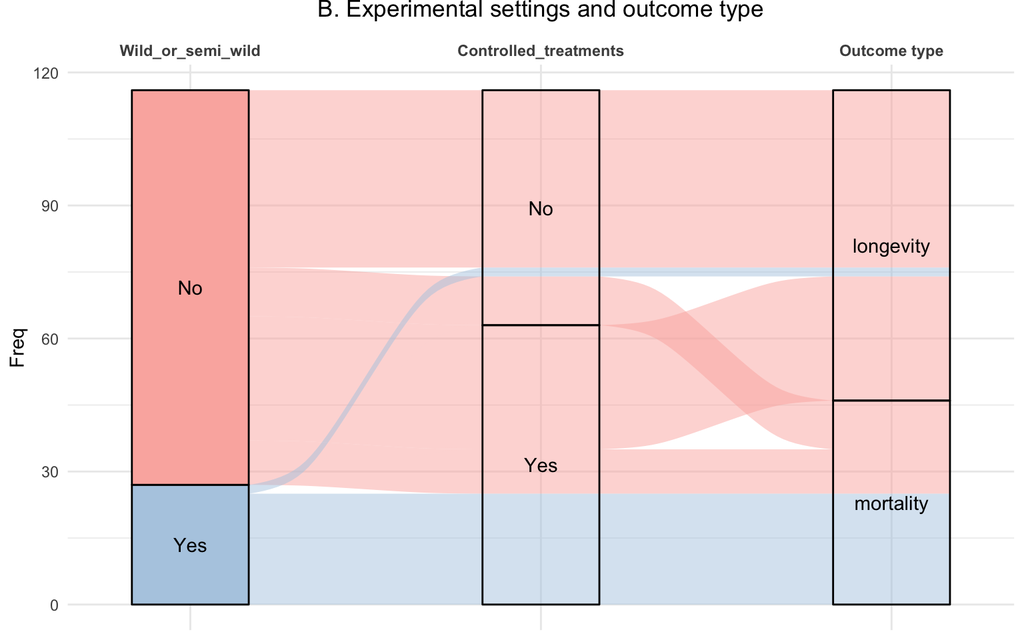

```r
# create a frequency table for next 3 moderator variables
freq_2 <- as.data.frame(table(dat$Wild_or_semi_wild, dat$Controlled_treatments, dat$Effect_type)) %>%
    rename(Wild_or_semi_wild = Var1, Controlled_treatments = Var2, Effect_type = Var3)
is_alluvia_form(as.data.frame(freq_2), axes = 1:3, silent = TRUE)
# freq_2 %>% filter(Freq != 0) %>% arrange(desc(Freq)) #collapesd table of
# values, without 0s

ggplot(data = freq_2, aes(axis1 = Wild_or_semi_wild, axis2 = Controlled_treatments,
    axis3 = Effect_type, y = Freq)) + geom_alluvium(aes(fill = Wild_or_semi_wild)) +
    geom_stratum(aes(fill = Wild_or_semi_wild)) + geom_text(stat = "stratum", aes(label = after_stat(stratum))) +
    theme_minimal() + # theme_void() +
theme(legend.position = "none", plot.title = element_text(hjust = 0.5, vjust = 3),
    axis.title.x = element_text(), axis.text.x = element_text(face = "bold")) + scale_x_discrete(limits = c("Wild_or_semi_wild",
    "Controlled_treatments", "Outcome type"), expand = c(0.15, 0.05), position = "top") +
    scale_fill_brewer(palette = "Pastel1") + ggtitle("B. Experimental settings and outcome type")
```

```r
# names(dat_key)
```

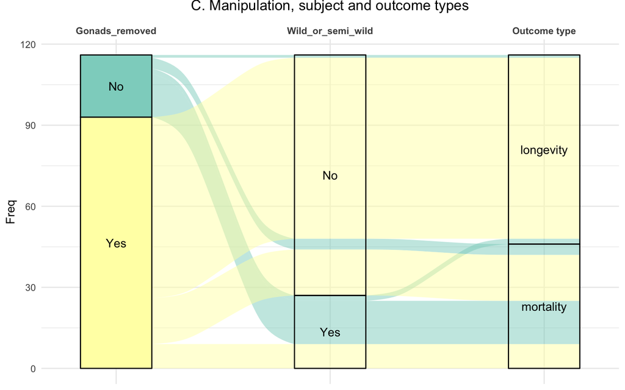

```r
# create a frequency table for next 3 moderator variables
freq_3 <- as.data.frame(table(dat$Gonads_removed, dat$Wild_or_semi_wild, dat$Effect_type)) %>%
    rename(Gonads_removed = Var1, Wild_or_semi_wild = Var2, Effect_type = Var3)
is_alluvia_form(as.data.frame(freq_3), axes = 1:3, silent = TRUE)
# freq_2 %>% filter(Freq != 0) %>% arrange(desc(Freq)) #collapesd table of
# values, without 0s

ggplot(data = freq_3, aes(axis1 = Gonads_removed, axis2 = Wild_or_semi_wild, axis3 = Effect_type,
    y = Freq)) + geom_alluvium(aes(fill = Gonads_removed)) + geom_stratum(aes(fill = Gonads_removed)) +
    geom_text(stat = "stratum", aes(label = after_stat(stratum))) + theme_minimal() +
    # theme_void() +
theme(legend.position = "none", plot.title = element_text(hjust = 0.5, vjust = 3),
    axis.title.x = element_text(), axis.text.x = element_text(face = "bold")) + scale_x_discrete(limits = c("Gonads_removed",
    "Wild_or_semi_wild", "Outcome type"), expand = c(0.15, 0.05), position = "top") +
    scale_fill_brewer(palette = "Set3") + ggtitle("C. Manipulation, subject and outcome types")
```

```r
# names(dat_key)
```

This just shows a different combination of predictor variables (moderators) from plots A and B.